# Question of interest:

### **Quality Issue 2(total): Feature engineering - Shoe Type Classification**

```python
# Shoe list of all shoes worn in NBA/WNBA games in the dataset
shoe_list  = df_2['Shoe Name'].unique().tolist()
```

#### 3. Dataset - Programmatical Low Top, Mid Top, and High Top Classification of Basketball Shoes

```python
# function to get low tops, mid-tops, and high-tops, respectively from runrepeat.com - if the shoe is worn during
# a game by one of the players in the dataset

def get_top_list(base_url, num_pages, shoe_list):
    tops_url_list = [base_url if i == 1 else f'{base_url}?page={i}' for i in range(1, num_pages + 1)]

    tops = set()

    for url in tops_url_list:
        response = requests.get(url)
        soup = BeautifulSoup(response.content, 'html.parser')
        product_elements = soup.find_all('a', {'data-v-1e9dcd0a': '', })

        for product_element in product_elements:
            product_name = product_element['href'].split('/')[-1]
            product_name = product_name.replace("-", " ").lower()
            if product_name in shoe_list:
                tops.add(product_name)
    ()
    return list(tops)
```

```python
# low Tops
low_base_url = 'https://runrepeat.com/catalog/low-top-basketball-shoes'
low_tops = get_top_list(low_base_url, 4, shoe_list)
print(len(low_tops))

# Mid Tops
mid_base_url = 'https://runrepeat.com/catalog/mid-top-basketball-shoes'
mid_tops = get_top_list(mid_base_url, 5, shoe_list)
print(len(mid_tops))

# High Tops
high_base_url = 'https://runrepeat.com/catalog/high-top-basketball-shoes'
high_tops = get_top_list(high_base_url, 2, shoe_list)
print(len(high_tops))
```

```
68
60
16
```

- low_tops
- mid_tops
- high_tops

```python
# manually getting remaining unclassified shoes:

manuals = []

_ = [manuals.append(i) for i in shoe_list if i not in low_tops and i not in mid_tops and i not in high_tops]

# creating batches of 50 to manually go through 50 shoes and categorise manually
batch_size = 50
manuals_batches = [manuals[i:i+batch_size] for i in range(0, len(manuals), batch_size)]
#batch_iter = iter(manuals_batches)
batch_iter = enumerate(manuals_batches, 1)
```

```python
print(len(manuals))
```

```
459
```

```python
# manually go through 9 batches and append respective lists after looking up shoes
# Iteration will be done in this code cell batch
next_batch = next(batch_iter)
print(f"Batch {next_batch[0]} of {len(manuals_batches)}:", next_batch[1])
```

```
Batch 1 of 10: ['air jordan 37', 'nike lebron xx', 'nike kobe 6', 'li ning jb1', 'nike air zoom g.t. cut 2', 'nike air zoom g.t. run', 'adidas crazylight boost 2016 low', 'puma trc blaze', 'nike air zoom g.t. cut', 'adidas harden vol. 3', 'nike kobe iv protro', 'nike air deldon 1', 'converse all sta…
```

```python
# add to tops lists manually batch by batch after looking up online (Batches 1-5):
low_tops.extend(['nike lebron xx', 'nike kobe 6', 'li ning jb1','nike air zoom g.t. cut 2',
                'adidas crazylight boost 2016 low','puma trc blaze','nike air zoom g.t. cut',
                'adidas harden vol. 3','nike kobe iv protro','converse all star bb evo low',
                'under armour spawn 5','nike kobe v','nike kobe 8','rigorer war ender',
                'new balance two wxy 3','nike ja 1','puma stewie 2','nike kobe 7',
                'nike sabrina 1','adidas trae young 2.0','under armour curry flow 10',
                'nike kyrie low 2','adidas d.o.n. issue 3','nike kd 6 elite',
                'adidas dame 7 extply','puma stewie 1','adidas d rose 1.5 low',
                'puma mb.01 low','adidas agent gil','reebok kamikaze low',
                # batch2:,
                'nike kobe xi low','peak aw1','anta kt splash 5.0','nike kd 16',
                'nike kyrie low 1','li ning way of wade 10 low',
                'puma playmaker pro','rigorer sniper 2','under armour curry 1 low flotro','jordan cp3.xii',
                'li ning wade son of flash','nike kd 3','under armour curry 2 low flotro',
                'puma court rider 2.0','adidas crazy byw x 2.0','adidas trae unlimited','nike kobe x low',
                '361 dvd 1','li ning wade all city 11 v1','li ning wade all city 8','serious player only player 1',
                'nike kobe 9 low','under armour curry 3z6','li ning cj 2','nike pg 1','puma court rider chaos',
                'li ning speed 9','nike lunar hypergamer low','new balance two wxy 2','adidas harden vol. 6',
                'nike pg 2.5',
                # batch3:
                'and1 attack 2.0','li ning wade all city 11','adidas d lillard 2','li ning speed 8 premium low',
                'jordan luka 2', 'nike kobe a.d. low 2017', '361 lava', 'nike kd 7','peak delly 1',
                'under armour curry hovr splash 2','anta gordon hayward gh3','li ning speed vii','li ning sonic 11',
                'anta shock wave 4 pro','adidas harden vol. 4','nike pg 2','new balance kawhi 2 low',
                'li ning wade 808 2 ultra','jordan why not? zer0.6','li ning yushuai xv v2 low', 'anta daringly 3.0',
                'qiaodan kj 1','adidas crazylight boost low 2015','361 ag3 pro low','xtep jlin 2 se',
                # batch4:
                'anta gh4','nike pg 3','li ning wade all city 10 v2','anta z up 1','nike lebron 9 low',
                'adidas crazylight boost 2.5','nike air adjust force x ambush',
                'li ning yushuai evolution low premium','peak taichi flash 4','anta gordon hayward gh2',
                '361 kontrol 3','jordan cp3.viii', 'anta shock the game 6','nike air rubber dunk off white',
                'adidas harden vol. 5','air jordan fusion 20 low','anta kt splash 4','nike kd 10',
                'li ning wade all city 9 v2','adidas harden vol. 1','li ning wade all city 10','nike lebron 11 low',
                'li ning yushuai xv low',
                # batch5:
                'reebok kamikaze low','li ning way of wade 2','adidas yeezy 500','adidas crazy explosive low 2017',
                'under armour curry 1 low','nike kd 7 elite','trezz 1','air jordan 11 low ie','li ning power ix',
                'air jordan 35 low','anta quick speed 5.0','nike hyperdunk 2008 low','nike kobe ad nxt 2017',
                'anta kt7 low','under armour curry 4 low','li ning yushuai xiv low','361 big3 3.0','puma triple',
                '361 kontrol 2','adidas t mac millennium','puma court rider twofold','li ning way of wade russel 1'])


mid_tops.extend(['nike air zoom g.t. run','nike air deldon 1','li ning way of wade 10','adidas harden vol. 7',
                'moolah neovolt pro','puma mb.02 low','adidas d.o.n. issue 4','jordan westbrook one take',
                'nike lebron 2','xtep battle','jordan why not? zer0.5',
                # batch2:
                'under armour embiid 1','converse all star bb jet','nike kobe ad mid','puma mb.02',
                'adidas adizero select','anta badao 2.0','new balance kawhi 3','puma mb.01',
                'nike kyrie s2 hybrid','li ning power viii','air jordan xxxiv',
                #batch3:
                'adidas tmac 3','adidas exhibit a mid','adidas crazylight boost 2014','under armour curry hovr splash',
                'nike zoom kd12','anta ufo alien 3.0','trezz 1 mid','jordan why not? zer0.1 chaos',
                'nike lebron soldier 11','nike kyrie s1 hybrid','adidas tmac 2','li ning yushuai 16 v2',
                #batch4:
                'air jordan 14 retro','li ning bad five iii','anta shock the game daringly 2.0',
                'peak surging technology triangle 2.0', 'puma playmaker pro mid','adidas pro n3xt 2021',
                'reebok answer 4','peak taichi andrew wiggins attitude','nike hyperdunk 2013','puma triple mid',
                'jordan jumpman pro','reebok iverson legacy','jordan why not? zer0.4',
                # batch5:
                'air jordan 4 retro','nike kd 5','adidas tmac 1','under armour hovr havoc 5 clone','jordan cp3.xi',
                'adidas d rose son of chi 2','jordan why not? zer0.1','air jordan 35','reebok answer v',
                'nike fly.by mid 3','li ning wade shadow 3','361 zen 3'])


high_tops.extend(['air jordan 37', 'air jordan 36', 'nike air zoom g.t. jump','361 ag3',
                 'nike kyrie infinity (kyrie 8)','air jordan 38','air jordan 11 retro',
                # batch2:
                 'anta kt8','air jordan 10','li ning wade 808 2 ultra v2','adidas d rose 1.5',
                 '361 ag3 pro','air jordan 1 retro','adidas d rose 1','nike kobe 1 protro',
                 #batch3:
                 'under armour hovr havoc 4', 'nike hyperdunk 2017','nike lebron 9','nike air force max ii',
                 'adidas d rose 5 boost','under armour curry 4 flotro', 'nike lebron 8','adidas top ten 2000',
                 'anta kt5','ethics lg 1','adidas crazy 1','anta frenzy 3',
                 #batch4:
                 'nike zoom huarache 2k4','air jordan 13 retro','nike lebron 11','jordan melo m13',
                 'reebok instapump fury zone','air jordan 12 retro','peak dh3','nike kobe x high',
                 'nike hyperdunk 2008','nike kobe 9 high elite', 'nike kobe 2 st','adidas rose 10',
                 # batch5:
                 'air jordan 9 retro','nike zoom lebron 3','nike kobe 3','louis vuitton trainer 2',
                 'nike kobe 9 high ext','nike lebron 9 ps elite','reebok the answer dmx','air jordan 2 retro',
                 'nike zoom hyperrev 2016','jordan super.fly mvp','air jordan 7 retro','nike hyperdunk 2011',
                 'jordan xx8 se','anta kt7', 'nike air foamposite one','nike lebron 12'])
'''
# unclear:
- adidas unknown 4
- 361 unknow
- unspecified sneaker
- 'qiaodan unknow'
- peak unknow
- 'anta unknow 8'

#will be deleted from list
'''
```

```
"\n# unclear:\n- adidas unknown 4\n- 361 unknow\n- unspecified sneaker\n- 'qiaodan unknow'\n- peak unknow\n- 'anta unknow 8'\n\n#will be deleted from list\n"
```

```python
# add to tops lists manually batch by batch after looking up online (Batches 6-10):
low_tops.extend(['air jordan xxxiv low','new balance two wxy low',
                'nike air force max low','nike lebron 8 v2 low',
                'adidas harden b/e 2','adidas d.o.n. issue 2',
                'nike lebron x','jordan cp3.xiii','peak flash 2',
                'under armour sc 3zer0 ii','peak taichi flash 3',
                'nike hyperdunk 2017 low','peak taichi flash',
                'anta shock the game 5','nike lebron ambassador 13',
                'under armour anatomix spawn 2','and1 override',
                'nike zoom lebron 20 5 5','li ning sonic x',
                'nike kobe mamba focus','anta kt6 low',
                'li ning way of wade all city 9','361 ag2x','361 ag2',
                'jordan cp3.vi','nike lebron x low','li ning way of wade 9 low',
                'converse all star pro bb low','nike lebron 17 low',
                #batch7:
                '361 menance','adidas harden vol. 2','li ning way of wade 7','under armour hovr havoc 3',
                'adidas pro bounce 2018 low','adidas d lillard 1','air jordan 13 retro low',
                'anta shock the game 5 assault 1','nike adapt bb 2.0','nike kd 5 elite',
                'under armour sc 3z5',  'nike lebron 12 low','anta kt5 light', 'air jordan 11 low retro',
                'new balance omn1s low','nike hyperdunk 2011 low','converse g4 ox','361 kyranbek',
                'li ning way of wade 4 low','li ning wade fission 7','nike hyperfuse low',
                #batch8:
                'anta gordon hayward gh1','anta rr6','anta kt5 low','nike kobe venomenon 4',
                'adidas harden b/e','under armour m tag low','li ning way of wade all city 6',
                'puma disc rebirth', 'adidas t mac millennium 2','anta shock the game 3.0 low',
                'anta kt the mountain','air jordan 32 low','puma legacy low','nike lebron 15 low',
                'nike cradle rocks','li ning yushuai 13 low',
                #batch9:
                'jordan jumpman diamond low','li ning sonic speed viii low',
                'anta kt4 light low','reebok dmx run 10','li ning yushuai 13 boom low',
                'nike lebron 8 v2','nike lebron 16 low','crossover culture kayo lp2',
                'nike zoom shift 1','air jordan 31 low','fila grant hill 1 & spaghetti low hybrid',
                'li ning speed vi premium','li ning wade all city 8 v2','li ning all city 7 one last dance',
                'nike zoom kobe venomenon 5','adidas d.o.n. issue 1','361 big 3',
                'under armour anatomix spawn low 2019','adidas pro adversary low 2019',
                #batch10:
                'q4 495 lo','nike air max 90','nike zoom shift 2','li ning way of wade 6',
                'k8iros 8.1'])


mid_tops.extend(['li ning cj 1','puma rs x mid','new balance the kawhi',
                'and1 tai chi','nike flytrap 4','nike kobe 2','anta badao',
                '361 ag1','adidas n3xt l3v3l futurenatural','and1 override',
                'air jordan 31','under armour hovr havoc 2','and1 tai chi 3',
                #batch7:
                'nike kyrie flytrap i','nike zoom lebron soldier 4','anta kt1','nike air precision 2',
                'jordan why not? zer0.3 se','j. cole x puma dreamer 2','nike air max2 cb','puma clyde court',
                'reebok zig encore','li ning yushuai xv','nike lebron 16 sb','adidas exhibit select',
                'jordan melo 1.5',
                #batch8:
                '361 ag1 se','air jordan xx 3/4','jordan jumpman 2021','adidas yzy bsktbl quantum',
                'nike kd trey 5 vii','adidas pro boost mid','adidas kobe 2','puma legacy 68',
                'jordan why not? zer0.2','jordan super.fly 6','reebok zpump rise','li ning way of wade 1',
                'jordan cp3.iv','nike kobe x ext','jordan cp3.ix',
                #batch9:
                'air jordan 22 low','nike zoom soldier iii','adidas zoneboost','nike precision iii',
                'reebok wall season 3','k8iros mark ii','adidas mad bounce 2018','adidas 98 x crazy byw',
                'reebok pump court victory 2 2009','nike air max dominate','adidas mad bounce 2017',
                'q4 the specialist',
                #batch10:
                'jordan jumpman diamond mid','jordan 2009 (24)', 'nike lebron icon'])

high_tops.extend(['air jordan xx','li ning yushuai 13 boom','air jordan 32',
                 'adidas n3xt l3v3l 2','nike air zoom generation (lebron 1)',
                 'air jordan 5 retro','reebok pump omni lite','nike hyperdunk 2016',
                 'adidas d howard light',
                 #batch7:
                 'adidas crazy 8 a/d','air jordan 18','adidas yzy bsktbl knit',
                 'adidas d rose 773 iv','reebok kamikaze ii','air jordan 30.5','adidas j wall 1',
                 'anta kt4','jordan xx8','nike air penny 3','nike hyperdunk 2012','jordan why not? zer0.3',
                 'new balance omn1s','adidas d rose 9','nike hyperdunk 2010',
                 #batch8:
                 'air jordan xxxiv se','adidas d howard 5','nike air penny 5','adidas tmac 5',
                 'air jordan 3 retro','anta kt3','puma sky dreamer','nike air flight one',
                 'anta kt6','reebok dee brown pump d time','nike shox bb4','reebok the rail',
                 'reebok shaq attaq 4','reebok pumpspective omni','reebok avant guard',
                 'nike lebron zoom soldier 1','nike zoom hyperfuse 2010',
                 #batch9:
                 'anta shock the game 4.0','nike air zoom huarache 2k5','reebok answer 11',
                 'adidas posterize','nike hyperdunk 2017 flyknit','jordan melo m10',
                 'li ning yushuai 13','nike air foamposite pro','adidas adipure crazyquick',
                 'li ning sonic viii','nike lebron 17 graffiti','nike air go lwp',
                 'jordan melo m11','air jordan 8 retro','air jordan 16','jordan melo 5.5',
                 '361 zen 00','adidas pro bounce 2019','adidas d rose 7',
                 #batch10:
                 'adidas harden b/e 3'])


'''
# unclear:

- 'unbranded shoes'
- 'li ning unknown'
- 'li ning unknown 2'

#will be deleted from list
'''
```

```
"\n# unclear:\n\n- 'unbranded shoes'\n- 'li ning unknown'\n- 'li ning unknown 2'\n\n#will be deleted from list\n"
```

**Procedure:** Classifying players shows according to shoe type proofed to be a somewhat tedious task as there are only limited central classifications available, and the shoe names and signature lines mostly did not specify or adhere to a specific shoe-height but where generally mixed. After attempt to programmatically classify shoe type with an additional web srape, effectively all 600 different shoes have been visually inspected to consider the heigt-cut in regards to ankle support, as this is the main investigative purpose of the project, the general procedural framework was:

1. If the manufacturer classified a show a certain cut, or added the cut height as part of the shoe-name, if visualy inspection did not contradict the name, the shoe was considered this type, e.g.: 'nike kobe xi low' == low-cut
2. Retailer classification was considered, e.g. if different retailer or collector classified the shoe a certain cut, for the shoes which are unclear in regards to being between 2 cuts, e.g. low/mid cut, the retailer classification was adhered to.
3. If no information was available the shoe was inspected and remaining shoes which are unclear and between low/mid cut, where generally considered low-cut, while mid/high cut, where generally considered high cut, and visually clear cuts simply classified according to their cuts.

In a small number of cases, visual inspections contradicted retail classification and it was opted for viscually classification.

```python
# add shoe and shoe type as tuples to lookup-table
lookup_table = []

_ = [lookup_table.append((i, "low")) for i in low_tops]
_ = [lookup_table.append((i, "mid")) for i in mid_tops]
_ = [lookup_table.append((i, "high")) for i in high_tops]
```

```python
len(lookup_table)
```

```
596
```

```python
#FILL IN - Apply the cleaning strategy
# create look up table for shoe name and shoe type - list of tuples (shoe-name, shoe-type)



# Create function to create and add column based on look-up table
# Define a function to look up the shoe type based on the shoe name
def get_shoe_type(row):
    for shoe_name, shoe_type in lookup_table:
        if shoe_name in row['Shoe Name']:
            return shoe_type
    return None

# Apply the function to each row of the dataframe and create a new column
df_2['Shoe Type'] = df_2.apply(get_shoe_type, axis=1)
```

```python
#FILL IN - Validate the cleaning was successful
df_2['Shoe Type'].value_counts()
```

```
low     72903
mid     28204
high     7377
Name: Shoe Type, dtype: int64
```

**Justification:** *Shown above is a programmatical solution for categorising shoe type for available shoes from a different webscrape datasource, and the shoe type is added to the dataframe if the shoe name in the respective category of the 3 data source match the name of a shoe in the list of shoes.*

### **Quality Issue 3: Drop observations which do not have shoe-type categorized**

```python
# Check how many observations have unspecified shoe-type, these are the shoes which where stated as worn, but unknown
df_2['Shoe Type'].isna().sum()
```

```
428
```

```python
# delete the rows with Nan value in shoe-type column
df_2 = df_2.dropna(subset=['Shoe Type'])
```

```python
# check if rows have been deleted
df_2['Shoe Type'].isna().sum()
```

```
0
```

### **Tidiness Issue 4: Drop "Acquired" column and related observations = NaN observations of "Relinquient"**

```python
#Apply the cleaning strategy
df_1 = df_1.drop('Acquired', axis=1)
df_1 = df_1.dropna(subset=['Relinquished'])
```

```python
#Validate the cleaning was successful
df_1.sample()
```

|  | Date | Team | Relinquished | Notes |
| --- | --- | --- | --- | --- |
| 33702 | 2021-12-06 | Wizards | Spencer Dinwiddie | placed on IL with right knee injury |

**Justification:** *For the research question it is not of general interest to know when the player returned from injury.*

### **Tidiness Issue 5: Drop "Team" column in Df_1**

```python
#Apply the cleaning strategy
df_1 = df_1.drop('Team', axis=1)
```

```python
#Validate the cleaning was successful
df_1.sample()
```

|  | Date | Relinquished | Notes |
| --- | --- | --- | --- |
| 32820 | 2021-05-05 | Khris Middleton | placed on IL with sore right knee |

**Justification:** *Not needed column for further analysis*

### **Tidiness Issue 6: Rename column "Relinquished" to "Player" in DF_1**

```python
#Apply the cleaning strategy
df_1 = df_1.rename(columns={'Relinquished': 'Player'})
```

```python
#Validate the cleaning was successful
df_1.sample()
```

|  | Date | Player | Notes |
| --- | --- | --- | --- |
| 32251 | 2021-03-27 | Hamidou Diallo | placed on IL with right groin injury |

**Justification:** *Column optimally used as additional identifier.*

# Subsequent Tidiness steps and full completion of additional player injury information will be done before showcasing, but current state ist sufficient for submission/proof of work

### **Unnecessary variables removed, combining datasets**

```python
df_1['Player'] = df_1['Player'].apply(lambda x: x.lower().strip())
df_2['Player'] = df_2['Player'].apply(lambda x: x.lower().strip())
```

```python
df_1.sample()
```

|  | Date | Player | Notes |
| --- | --- | --- | --- |
| 32294 | 2021-03-29 | gorgui dieng | placed on IL |

```python
df_1.info()
```

```
<class 'pandas.core.frame.DataFrame'>
Int64Index: 3878 entries, 30252 to 37633
Data columns (total 3 columns):
 #   Column  Non-Null Count  Dtype
---  ------  --------------  -----
 0   Date    3878 non-null   datetime64[ns]
 1   Player  3878 non-null   object
 2   Notes   3878 non-null   object
dtypes: datetime64[ns](1), object(2)
memory usage: 121.2+ KB
```

```python
df_1.shape[0]
```

```
3878
```

```python
date_min = df_1['Date'].min()
date_max = df_1['Date'].max()

print('Date range:', date_min, 'to', date_max)
```

```
Date range: 2019-12-25 00:00:00 to 2023-04-09 00:00:00
```

```python
# Prior to merge, we need to make sure to catch the
df_1 = df_1.reset_index(drop=True)
# Create a range of dates for +-7 days
date_range = pd.date_range(start=df_1['Date'][0] - pd.Timedelta(days=7), end=df_1['Date'][0] + pd.Timedelta(days=7), freq='D')

# Create a list of dataframes with the original observation for each date in the range
dfs = [df_1.copy() for _ in range(len(date_range))]
for i, date in enumerate(date_range):
    dfs[i]['Date'] = date

# Concatenate the original dataframe with the new dataframes
new_df = pd.concat(dfs, ignore_index=True)

# Print shape of the resulting dataframe
new_df.shape
```

```
(58170, 3)
```

```python
#Combine datasets
merged_df = pd.merge(new_df, df_2, on=['Date','Player'])
```

```python
merged_df.sample(10)
```

|  | Date | Player | Notes | Shoe Name | Points | Rebounds | Assists | Steals | Blocks | Minutes | Shoe Type |
| --- | --- | --- | --- | --- | --- | --- | --- | --- | --- | --- | --- |
| 1067 | 2020-01-01 | jaylen nowell | placed on IL with tibia injury | nike kyrie 5 | 12 | 2 | 0 | 0 | 1 | 15 | mid |
| 385 | 2019-12-26 | joe ingles | placed on IL with NBA health and safety protocols | nike kobe ad mid | 26 | 5 | 4 | 1 | 0 | 35 | low |
| 622 | 2019-12-28 | myles turner | placed on IL with sore left foot (out for season) | nike pg 1 | 9 | 6 | 2 | 0 | 0 | 22 | low |
| 239 | 2019-12-25 | romeo langford | placed on IL with sprained left ankle | air jordan xx | 2 | 2 | 0 | 1 | 0 | 20 | high |
| 9 | 2019-12-19 | patrick beverley | placed on IL with left hand injury | adidas harden vol. 4 | 10 | 2 | 7 | 4 | 1 | 29 | low |
| 506 | 2019-12-27 | jimmy butler | placed on IL with right knee injury | air jordan 31 | 20 | 9 | 6 | 1 | 0 | 32 | mid |
| 748 | 2019-12-28 | thanasis antetokounmpo | placed on IL with NBA health and safety protocols | nike zoom freak 1 | 0 | 0 | 0 | 0 | 0 | 0 | mid |
| 671 | 2019-12-28 | brandon clarke | placed on IL with right hip injury | nike pg 2.5 | 15 | 2 | 5 | 0 | 1 | 22 | low |
| 313 | 2019-12-26 | markieff morris | placed on IL with illness | nike kobe iv protro | 4 | 2 | 1 | 0 | 0 | 8 | low |
| 37 | 2019-12-19 | kyle korver | placed on IL with sore back | nike zoom freak 1 | 6 | 0 | 0 | 1 | 0 | 13 | mid |

```python
merged_df.shape
```

```
(1113, 11)
```

## 4. Update your data store

Update your local database/data store with the cleaned data, following best practices for storing your cleaned data:

- Must maintain different instances / versions of data (raw and cleaned data)
- Must name the dataset files informatively
- Ensure both the raw and cleaned data is saved to your database/data store

```python
#FILL IN - saving data
merged_df.to_csv('merged_data.csv', index=False)
```

## 5. Answer the research question

### **5.1:** Are low top shoes player less injury prown to ankle strains?

Going back to the problem statement in step 1, use the cleaned data to answer the question you raised. Produce **at least** two visualizations using the cleaned data and explain how they help you answer the question.

```python
ankle_df = merged_df.query('Notes.str.contains("ankle")')
```

```python
ankle_df = ankle_df.dropna(subset=['Shoe Type'])
```

```python
ankle_df.sample(5)
```

|  | Date | Player | Notes | Shoe Name | Points | Rebounds | Assists | Steals | Blocks | Minutes | Shoe Type |
| --- | --- | --- | --- | --- | --- | --- | --- | --- | --- | --- | --- |
| 871 | 2019-12-30 | kris dunn | placed on IL with sprained right ankle | adidas pro vision | 4 | 2 | 2 | 1 | 0 | 19 | mid |
| 269 | 2019-12-25 | jrue holiday | placed on IL with sore left ankle | nike kyrie 6 | 20 | 4 | 8 | 6 | 0 | 31 | mid |
| 290 | 2019-12-25 | danuel house jr. | placed on IL with sprained right ankle | nike pg 3 | 18 | 5 | 0 | 1 | 1 | 34 | low |
| 876 | 2019-12-30 | jimmy butler | placed on IL with sore right ankle | air jordan 31 | 27 | 6 | 4 | 0 | 0 | 36 | mid |
| 797 | 2019-12-29 | eric gordon | placed on IL with sprained left ankle | adidas pro bounce 2019 low | 20 | 1 | 3 | 1 | 0 | 22 | low |

```python
ankle_df = ankle_df.drop_duplicates()
```

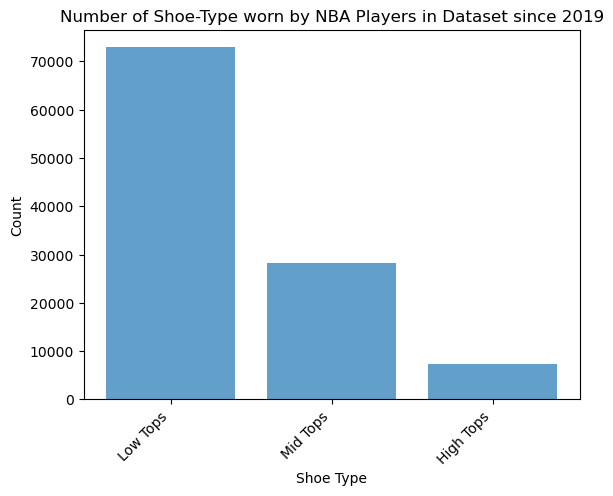

```python
# Visual 1: pie chart that shoes the composition of Shoe Type since 2019:
# Get the counts of each shoe type
# Get the counts of each shoe type
shoe_counts = df_2['Shoe Type'].value_counts()

# Create a bar chart using the counts of each shoe type
plt.bar(shoe_counts.index, shoe_counts.values,  alpha=0.7)

# Add a title
plt.title('Number of Shoe-Type worn by NBA Players in Dataset since 2019')

# Add x-axis and y-axis labels
plt.xlabel('Shoe Type')
plt.ylabel('Count')

# Define custom labels
labels = ['Low Tops', 'Mid Tops', 'High Tops']

# Customize the x-ticks with custom labels
plt.xticks(range(len(shoe_counts.index)), labels, rotation=45, ha='right')

# Show the plot
plt.show()
```

**Answer 1 to research question:** * The countplot above gives a visual of the overall usage of each type of shoe

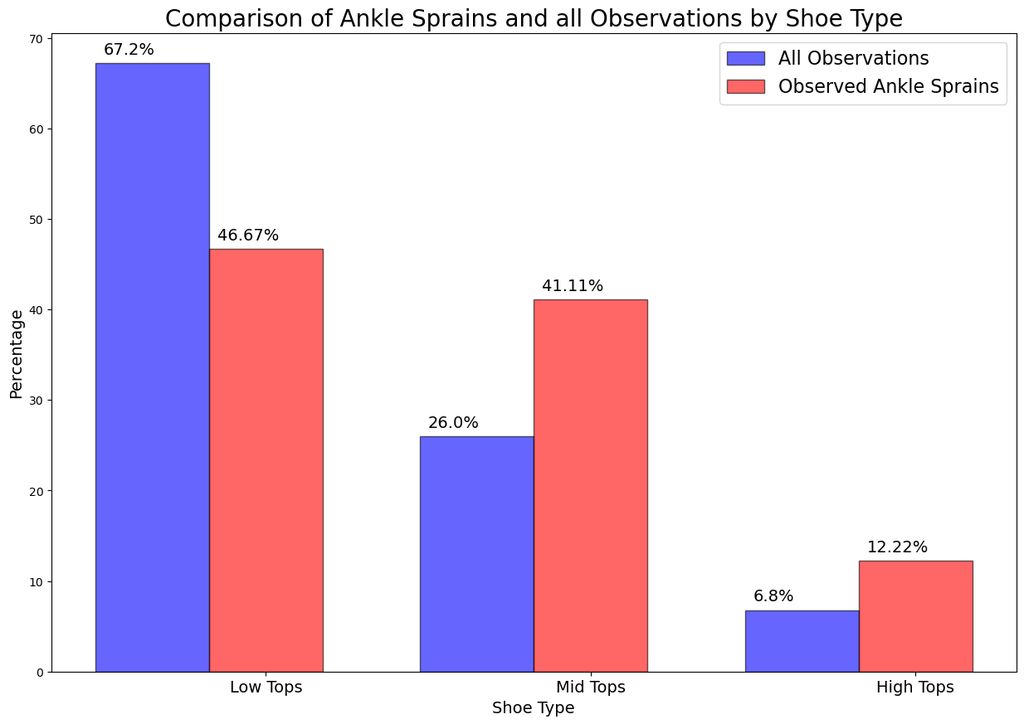

```python
# Data
labels = ['Low Tops', 'Mid Tops', 'High Tops']
dataset1 = df_2['Shoe Type'].value_counts()
dataset2 = ankle_df['Shoe Type'].value_counts()

# Calculate percentages
total1 = len(df_2)
total2 = len(ankle_df)
percent1 = [i/total1*100 for i in dataset1]
percent2 = [i/total2*100 for i in dataset2]

# Set the width of the bars
bar_width = 0.35

# Set the positions of the bars on the x-axis
r1 = np.arange(len(dataset1))
r2 = [x + bar_width for x in r1]

# Set the size of the figure
plt.figure(figsize=(15, 10))

# Plot the bars
plt.bar(r1, percent1, color='blue', width=bar_width, edgecolor='black', label='All Observations', alpha=0.6)
plt.bar(r2, percent2, color='red', width=bar_width, edgecolor='black', label='Observed Ankle Sprains',alpha=0.6)

# Add xticks on the middle of the group bars
plt.xlabel('Shoe Type',fontsize=14)
plt.ylabel('Percentage',fontsize=14)
plt.xticks([r + bar_width for r in range(len(dataset1))], labels, fontsize=14)
plt.title('Comparison of Ankle Sprains and all Observations by Shoe Type',fontsize=20)
# Add percentages on the bars
for i, v in enumerate(percent1):
    plt.text(i - 0.15, v + 1, str(round(v, 2)) + '%',fontsize=14)
for i, v in enumerate(percent2):
    plt.text(i + bar_width - 0.15, v + 1, str(round(v, 2)) + '%',fontsize=14)

# Create legend & Show graphic
plt.legend(fontsize=16)
plt.show()
```

Please regard the submission at this point as proof of concept, and see below for next needed steps on improvement and consolidation of insights.

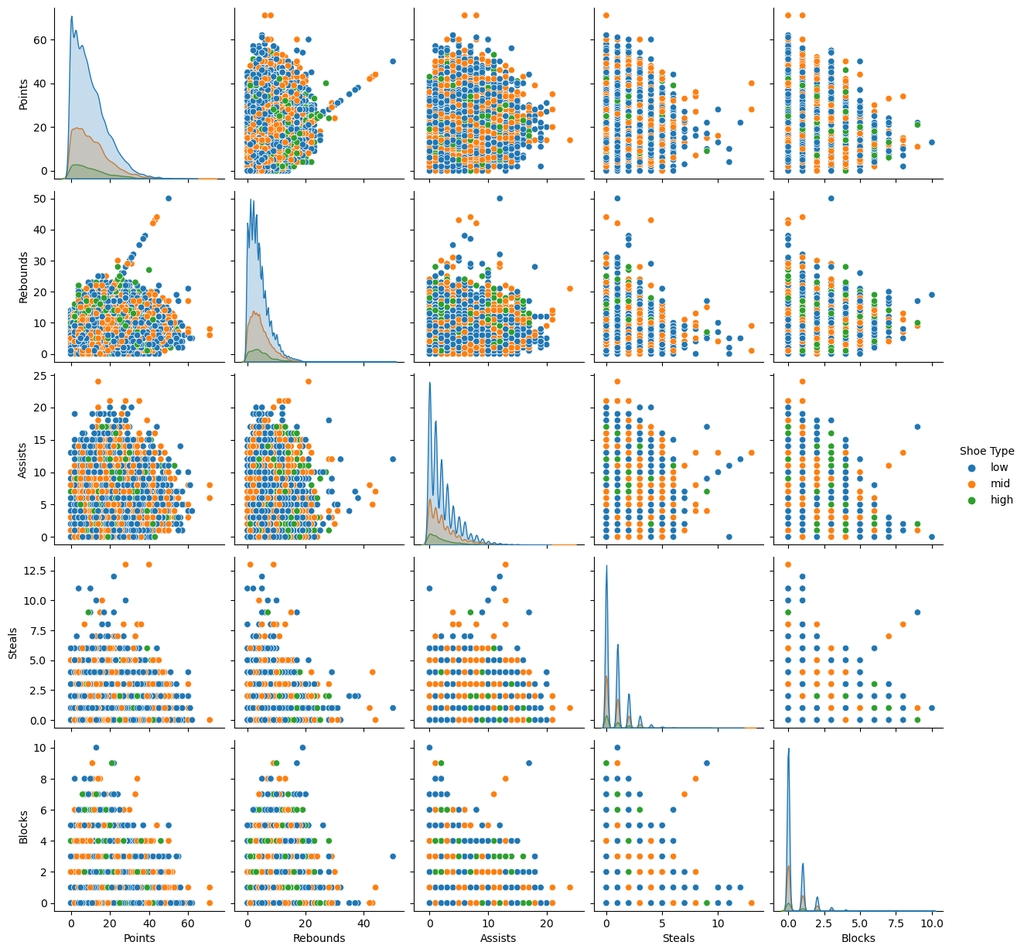

```python
numerical_variables = ['Points', 'Rebounds', 'Assists', 'Steals', 'Blocks']

# Create a pairplot with the hue set to "Shoe Type"
sns.pairplot(df_2[numerical_variables + ['Shoe Type']], hue='Shoe Type');
```

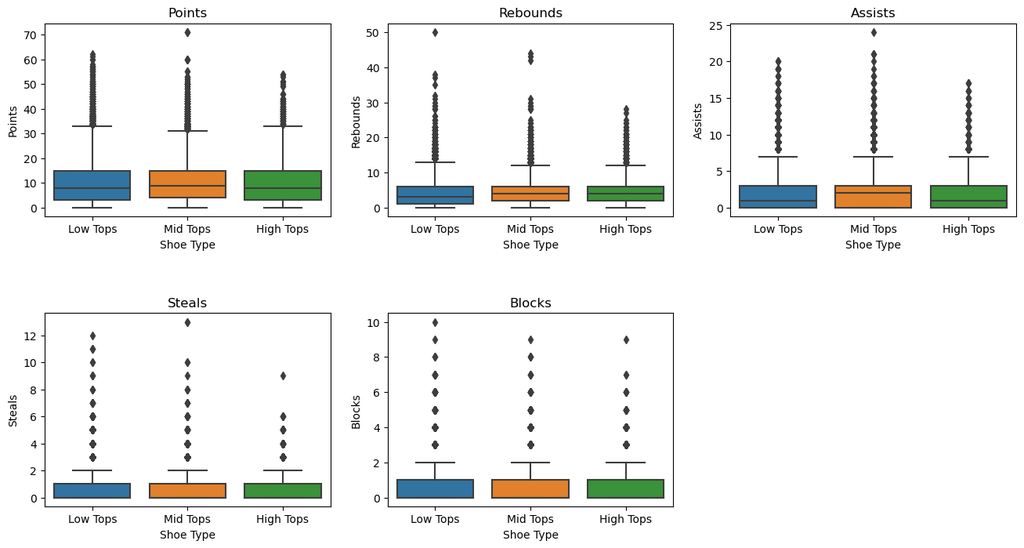

```python
# Define the numerical variables
numerical_variables = ['Points', 'Rebounds', 'Assists', 'Steals', 'Blocks']
labels = ['Low Tops', 'Mid Tops', 'High Tops']
# Create a figure with two subplots
fig, axs = plt.subplots(nrows=2, ncols=3, figsize=(16, 8))

# Loop through the numerical variables and create a catplot for each subplot
for i, variable in enumerate(numerical_variables):
    sns.boxplot(x='Shoe Type', y=variable, data=df_2, ax=axs[i//3, i%3])
    axs[i//3, i%3].set_xticklabels(labels)


# Set the title for each subplot
axs[0, 0].set_title('Points')
axs[0, 1].set_title('Rebounds')
axs[0, 2].set_title('Assists')
axs[1, 0].set_title('Steals')
axs[1, 1].set_title('Blocks')

# Adjust the spacing between the subplots
fig.subplots_adjust(hspace=0.5)

# Remove the last subplot (bottom-right)
plt.delaxes(axs[1, -1])

# Show the plot
plt.show()
```

Overall the differences in performance appear to be limited.

### **5.2:** Reflection

*Answer:* Now given the time limit for submission the remaining dataframe is short, the webscraping has high volume data of high quality, however the first dataset, the injury list, is not as complete and comprehensive as would be beneficial, a better solution was for example to scrape the injury report from the source that was used to manually complete the injury information for individual rows, now given the project guidelines it was asked to use at least 2 different methods of data-gathering, hence for the first dataset a direct download was chosen.

Now when having manually completed the intermediate steps before, like manually adding reasons for placement on injury list, like was done in quality issue 1, doing this for all players will again result in an increase in the masked remaining dataset, which should be done before showcasing the project.

Further the project can be expanded to equally investigate achilles tendon injuries, and in regards to performance, the shoe brand and type could both be considered for performance comparisons of athletes.

Limitations: It is not entirely given, that a player wears the same shoe during training, like during games, on the other hand, this is highly likely, given that it may be possible that a sprained ankle may have occured during training with another shoe type.